# MVA_Practical_1

Zane Hassoun

1/31/2022

# Multivariate Analysis Practical 1

#### Using the PanTHERIA dataset

#### Questions 1&2 Download file and format the values

```r
raw_data = read.csv("C:/Users/zaneh/Downloads/ECOL_90_184/PanTHERIA_1-0_WR05_Aug2008.txt", sep = "\t")
rownames(raw_data) <- raw_data$MSW05_Binomial
# Keep only relevant variables
raw_data_vars <- raw_data[,c(7, 9, 16, 21, 22, 23)]
# Give readable column names
colnames(raw_data_vars) <- c("body_mass_g", "body_length_mm", "gestation_length_d",
"litter_size", "litters_per_year", "longevity_m")
# Find indices of rows that have missing values (equal to -999)
which_na <- sapply(1:nrow(raw_data_vars), function(i) any(raw_data_vars[i,] == -999))
# Remove those rows from data
data <- raw_data_vars[!which_na,]

head(data)
```

```
##                     body_mass_g body_length_mm gestation_length_d litter_size
## Canis lupus            31756.51        1055.00              63.50        4.98
## Bos frontalis         800143.05        2700.00             273.75        1.22
## Bos javanicus         635974.34        2075.00             296.78        1.22
## Caluromys philander      246.47         224.27              23.99        4.18
## Atelerix algirus         903.98         214.76              39.25        2.50
## Callorhinus ursinus    55464.82        1734.82             358.49        1.04
##                     litters_per_year longevity_m
## Canis lupus                      2.0      354.00
## Bos frontalis                    1.0      314.40
## Bos javanicus                    1.0      318.96
## Caluromys philander              2.0       76.00
## Atelerix algirus                 2.0       84.00
## Callorhinus ursinus              0.5      420.00
```

#### Q3 Create a scatterplot of body mass against body length. What is the relationship between the two variables?

The relationship is increasing

[figure not shown]

```r
#ggplot(data[which(data$body_length_mm<5000),])

ggplot(data) +
  geom_point(aes(x = log(body_mass_g), y = body_length_mm), colour = 'red') +
  labs(title = "Body Mass v Body Length", y = "Body Length", x = "Log(Body Mass)", subtitle = "Max Body Length 5,000")
```

#### Q4 Create a 3d scatterplot of any three variables in the data set (e.g., body length, litter size, and longevity). For this, you can use the function scatterplot3d from the package of the same name. You can change the angle argument to visualise the points from different angles. What is the relationship between the three variables?

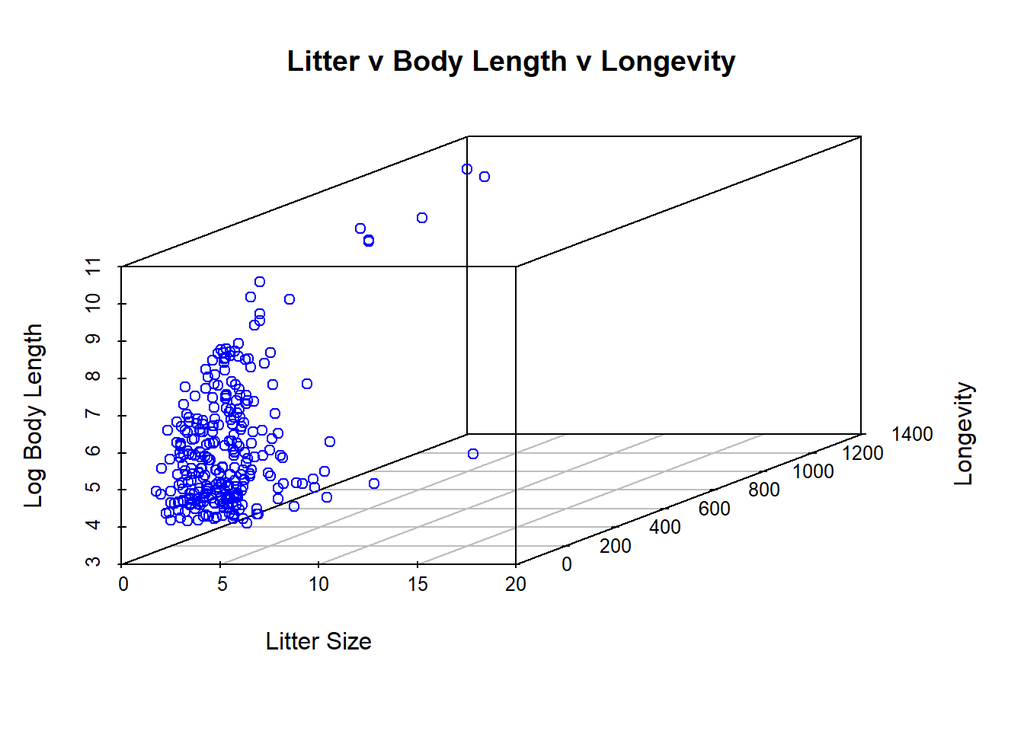

```r
scatterplot3d(x = data$litter_size,
              xlab = "Litter Size",
              z = log(data$body_length_mm),
              zlab = "Log Body Length",
              y = data$longevity_m,
              ylab = "Longevity",
              angle = 45,
              color = "blue",
              main = "Litter v Body Length v Longevity")
```

#### Question 5 Create a scatterplot matrix of all variables, using the function pairs. Can you easily identify pairs of variables that are correlated? (Alternatively, if you are familiar with ggplot2, you can use the function ggpairs from the package GGally.)

Correlated Variables: 1) Gestation Length & Longevity 2) Body Length & Longevity

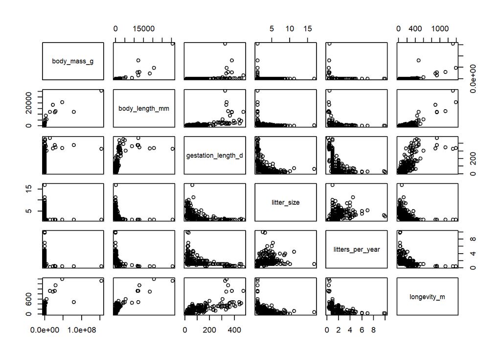

```r
pairs(data)
```

#### Question 6 Compute Correlation Matrix and 7 Create a correlogram

```r
print(cor(data))
```

```
##                    body_mass_g body_length_mm gestation_length_d litter_size
## body_mass_g          1.0000000      0.8526265          0.3127310  -0.1316665
## body_length_mm       0.8526265      1.0000000          0.5792260  -0.2523107
## gestation_length_d   0.3127310      0.5792260          1.0000000  -0.5390654
## litter_size         -0.1316665     -0.2523107         -0.5390654   1.0000000
## litters_per_year    -0.1345477     -0.2353544         -0.4020840   0.2444923
## longevity_m          0.5971228      0.8327524          0.7330304  -0.4740162
##                    litters_per_year longevity_m
## body_mass_g              -0.1345477   0.5971228
## body_length_mm           -0.2353544   0.8327524
## gestation_length_d       -0.4020840   0.7330304
## litter_size               0.2444923  -0.4740162
## litters_per_year          1.0000000  -0.3753546
## longevity_m              -0.3753546   1.0000000
```

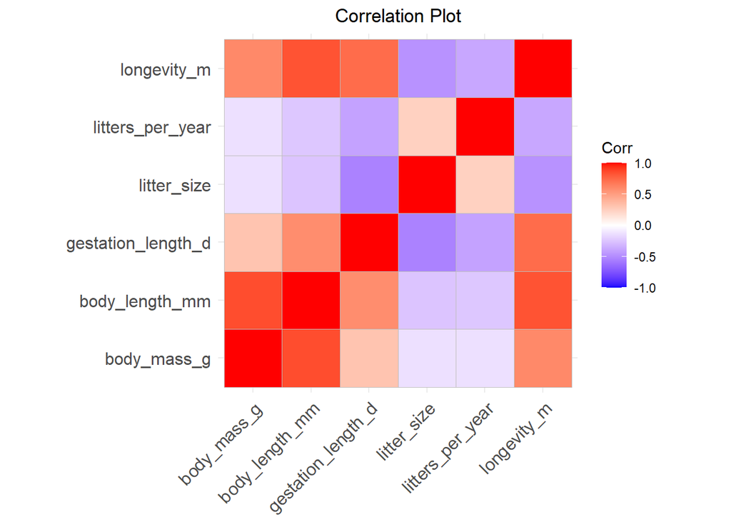

```r
ggcorrplot(cor(data)) + labs(title = 'Correlation Plot') + theme(plot.title = element_text(hjust = 0.5))
```

#### Question 10 Create star glyphs using the function stars. You can use the option key.loc to specify the coordinates at which the key should be placed.

#### Question 11. Create Chernoff faces using the function faces from the package aplpack.

#### Question 12. Compare the three types of plots to answer some common questions in multivariate analyses: Are there outliers in the data? Can you identify groups of similar data units?

```r
data_subset = data.frame(data[1:20,],species = rep(c("A", "B", "C","D"), 5))
data_subset
```

```
##                        body_mass_g body_length_mm gestation_length_d
## Canis lupus               31756.51        1055.00              63.50
## Bos frontalis            800143.05        2700.00             273.75
## Bos javanicus            635974.34        2075.00             296.78
## Caluromys philander         246.47         224.27              23.99
## Atelerix algirus            903.98         214.76              39.25
## Callorhinus ursinus       55464.82        1734.82             358.49
## Atherurus africanus        2875.65         430.99             108.18
## Atilax paludinosus         3600.16         499.01              77.27
## Babyrousa babyrussa       92950.09         950.00             156.50
## Balaenoptera musculus 154321304.50       30480.00             326.97
## Balaenoptera physalus  47506008.23       20641.06             338.36
## Chaetodipus fallax           19.19          83.35              25.00
## Chaetodipus formosus         20.02         193.91              28.00
## Equus zebra              282462.13        2350.00             363.49
## Erinaceus europaeus         777.95         237.17              36.98
## Eptesicus serotinus          23.09          67.99              65.44
## Equus grevyi             408000.35        2700.00             406.00
## Delphinapterus leucas   1381640.73        4249.83             394.24
## Bison bison              624577.07        2849.24             283.17
## Bison bonasus            675876.70        2900.00             265.99
##                       litter_size litters_per_year longevity_m species
## Canis lupus                  4.98             2.00      354.00       A
## Bos frontalis                1.22             1.00      314.40       B
## Bos javanicus                1.22             1.00      318.96       C
## Caluromys philander          4.18             2.00       76.00       D
## Atelerix algirus             2.50             2.00       84.00       A
## Callorhinus ursinus          1.04             0.50      420.00       B
## Atherurus africanus          1.50             2.75      274.80       C
## Atilax paludinosus           2.00             2.00      209.00       D
## Babyrousa babyrussa          1.73             1.50      288.00       A
## Balaenoptera musculus        1.00             0.45     1320.00       B
## Balaenoptera physalus        1.01             0.37     1392.00       C
## Chaetodipus fallax           3.45             1.00       99.60       D
## Chaetodipus formosus         5.28             1.00       60.00       A
## Equus zebra                  1.00             0.35      288.00       B
## Erinaceus europaeus          4.64             1.50      168.00       C
## Eptesicus serotinus          1.50             1.00       72.00       D
## Equus grevyi                 1.00             0.50      312.00       A
## Delphinapterus leucas        1.02             0.41      480.00       B
## Bison bison                  0.98             1.00      396.00       C
## Bison bonasus                1.00             1.00      324.00       D
```

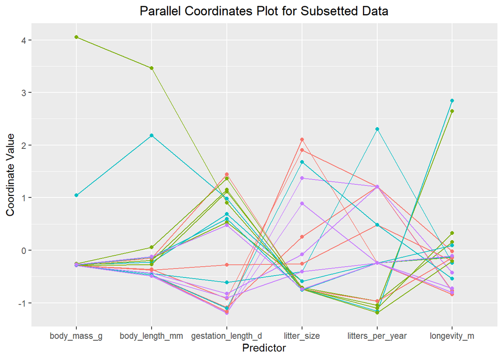

```r
ggparcoord(data_subset,showPoints = TRUE, columns = 1:6, groupColumn = "species")+
           labs(title = 'Parallel Coordinates Plot for Subsetted Data',
                              y = "Coordinate Value", x = "Predictor") +  theme(legend.position="none") + theme(plot.title = element_text(hjust = 0.5))
```

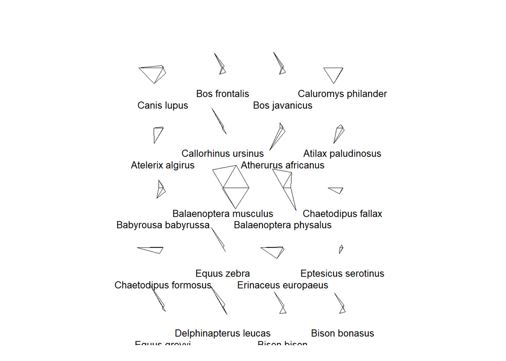

```r
stars(data[1:20,])
```

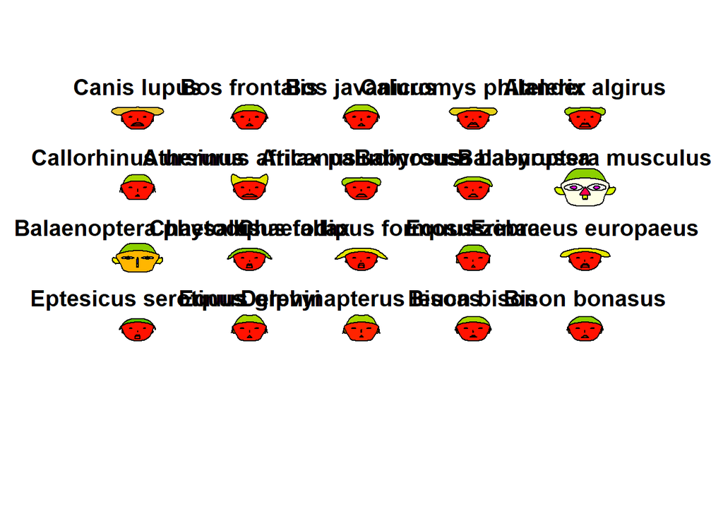

```
## effect of variables:
##  modified item       Var
##  "height of face   " "body_mass_g"
##  "width of face    " "body_length_mm"
##  "structure of face" "gestation_length_d"
##  "height of mouth  " "litter_size"
##  "width of mouth   " "litters_per_year"
##  "smiling          " "longevity_m"
##  "height of eyes   " "body_mass_g"
##  "width of eyes    " "body_length_mm"
##  "height of hair   " "gestation_length_d"
##  "width of hair   "  "litter_size"
##  "style of hair   "  "litters_per_year"
##  "height of nose  "  "longevity_m"
##  "width of nose   "  "body_mass_g"
##  "width of ear    "  "body_length_mm"
##  "height of ear   "  "gestation_length_d"
```

```r
faces(data[1:20,])
```

#### Question 13 - 16 Distance Matricies

New Dataset with scaled function D matrix using dist which are closes findings change using manhattan

```r
#Scaling the data
scaled_data = scale(data[1:20,])

#Computing the Distance Matrix

dist(scaled_data)
```

```
##                       Canis lupus Bos frontalis Bos javanicus
## Bos frontalis           3.2411359
## Bos javanicus           3.3106901     0.1789884
## Caluromys philander     0.9787624     3.0795370     3.1666669
## Atelerix algirus        1.8178686     2.4428116     2.5450578
## Callorhinus ursinus     3.9727892     0.9933399     0.8971748
## Atherurus africanus     2.5830570     2.8143992     2.8759107
## Atilax paludinosus      2.0211005     2.0952866     2.1941022
## Babyrousa babyrussa     2.3717515     1.1644206     1.2688276
## Balaenoptera musculus   7.4830356     6.3440756     6.3810998
## Balaenoptera physalus   5.7140612     4.1338027     4.1586188
## Chaetodipus fallax      1.9307347     2.3676062     2.4784992
## Chaetodipus formosus    1.6995613     3.2764897     3.3572744
## Equus zebra             4.1333694     1.1430972     1.0658920
## Erinaceus europaeus     0.9428397     2.9353113     3.0208684
## Eptesicus serotinus     2.8411936     1.6333193     1.7657852
## Equus grevyi            4.1693538     1.1763163     1.0609635
## Delphinapterus leucas   4.2143361     1.3023389     1.2186280
## Bison bison             3.3952711     0.2843175     0.2993712
## Bison bonasus           3.3329664     0.1599064     0.2795546
##                       Caluromys philander Atelerix algirus Callorhinus ursinus
## Bos frontalis
## Bos javanicus
## Caluromys philander
## Atelerix algirus                1.1199494
## Callorhinus ursinus             3.9211081        3.3846952
## Atherurus africanus             2.2344997        1.4614493           3.7391419
## Atilax paludinosus              1.5375525        0.5473740           3.0496735
## Babyrousa babyrussa             2.0881884        1.3311431           2.1007001
## Balaenoptera musculus           7.7508607        7.4861648           6.2505970
## Balaenoptera physalus           6.0667106        5.7234771           3.8843874
## Chaetodipus fallax              1.5347782        1.5891713           3.0355083
## Chaetodipus formosus            1.6284259        2.3514937           3.8311165
## Equus zebra                     4.0154977        3.4864271           0.4347359
## Erinaceus europaeus             0.8336134        1.6123286           3.6427376
## Eptesicus serotinus             2.3153970        1.6095682           2.3843054
## Equus grevyi                    4.0859183        3.5582378           0.4616483
## Delphinapterus leucas           4.2188232        3.7136844           0.4623983
## Bison bison                     3.2746716        2.6131549           0.9091278
## Bison bonasus                   3.1542695        2.4734389           1.0153606
```

[output cut: 105 more lines]

```
## Callorhinus ursinus
## Atherurus africanus
## Atilax paludinosus
## Babyrousa babyrussa
## Balaenoptera musculus
## Balaenoptera physalus
## Chaetodipus fallax
## Chaetodipus formosus
## Equus zebra
## Erinaceus europaeus
## Eptesicus serotinus
## Equus grevyi
## Delphinapterus leucas
## Bison bison
## Bison bonasus           0.2320975
```

```r
dist(scaled_data, method = "manhattan")
```

```
##                       Canis lupus Bos frontalis Bos javanicus
## Bos frontalis           5.7455871
## Bos javanicus           5.8061288     0.2573627
## Caluromys philander     1.6805613     6.1456042     6.2313482
## Atelerix algirus        2.6691129     4.9046237     4.9903677
## Callorhinus ursinus     7.1038713     1.8698503     1.6124876
## Atherurus africanus     4.0093251     4.3009741     4.3867181
## Atilax paludinosus      2.5461309     3.9280103     4.0137544
## Babyrousa babyrussa     3.7235427     2.1952304     2.2809745
## Balaenoptera musculus  17.5527239    12.0259992    11.9402551
## Balaenoptera physalus  13.6526610     8.1259362     8.0401921
## Chaetodipus fallax      3.5658183     4.1525944     4.2383385
## Chaetodipus formosus    2.8240144     5.4412573     5.5270013
## Equus zebra             7.4694382     1.8439471     1.6832288
## Erinaceus europaeus     1.7571172     5.3778862     5.4636302
## Eptesicus serotinus     4.6856727     2.6578195     2.7435635
## Equus grevyi            7.5273075     1.8038165     1.7340244
## Delphinapterus leucas   8.0246682     2.4979434     2.4121994
## Bison bison             5.9909272     0.4740950     0.5669720
## Bison bonasus           5.8339582     0.2555492     0.4807075
##                       Caluromys philander Atelerix algirus Callorhinus ursinus
## Bos frontalis
## Bos javanicus
## Caluromys philander
## Atelerix algirus                1.2434511
## Callorhinus ursinus             7.7227507        6.4817702
## Atherurus africanus             4.0267416        2.7857610           5.8781206
## Atilax paludinosus              2.2175938        0.9766133           5.5051569
## Babyrousa babyrussa             3.9503737        2.7093932           3.7744892
## Balaenoptera musculus          18.1716033       16.9306228          10.8839523
## Balaenoptera physalus          14.2715404       13.0305598           6.8266626
## Chaetodipus fallax              2.0296320        2.2436712           5.7297410
## Chaetodipus formosus            2.2604888        3.4461155           7.0184038
## Equus zebra                     7.7235471        6.4825666           0.7303374
## Erinaceus europaeus             1.3781851        2.3980787           6.9550327
## Eptesicus serotinus             3.5505044        2.3513050           4.2349660
## Equus grevyi                    7.9140603        6.6730797           0.7882067
## Delphinapterus leucas           8.6435476        7.4025671           0.9207968
## Bison bison                     6.6098066        5.3688261           1.5141523
## Bison bonasus                   6.2870329        5.0460523           1.8264615
```

[output cut: 105 more lines]

```
## Callorhinus ursinus
## Atherurus africanus
## Atilax paludinosus
## Babyrousa babyrussa
## Balaenoptera musculus
## Balaenoptera physalus
## Chaetodipus fallax
## Chaetodipus formosus
## Equus zebra
## Erinaceus europaeus
## Eptesicus serotinus
## Equus grevyi
## Delphinapterus leucas
## Bison bison
## Bison bonasus           0.3388512
```